# IODS course project

# Assignment 5

First let’s load up the data we’ll need.

```r
library(dplyr)
human <- read.table("https://raw.githubusercontent.com/KimmoVehkalahti/Helsinki-Open-Data-Science/master/datasets/human2.txt", sep = ",", header = T)
```

We’ve narrowed the data down in our data wrangling exercise. This data comes from the UN Development Program’s Human Development Index (HDI), and it has been paired down to simplify some of the missing pieces in the data.

## 1 Show a graphical overview of the data

Let’s take a look at what’s inside our data file ‘human’

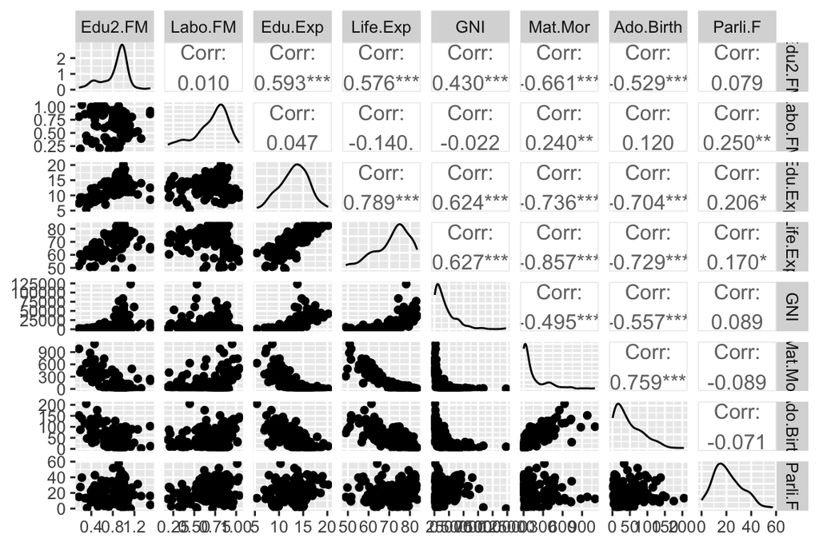

```r
library(GGally)
ggpairs(human)
```

Here we can see lots of interesting correlations in our data set. For example, note the strong correlation between variables like life expectancy, and the expected number of years of education.

```r
summary(human)
```

```
##     Edu2.FM          Labo.FM          Edu.Exp         Life.Exp
##  Min.   :0.1717   Min.   :0.1857   Min.   : 5.40   Min.   :49.00
##  1st Qu.:0.7264   1st Qu.:0.5984   1st Qu.:11.25   1st Qu.:66.30
##  Median :0.9375   Median :0.7535   Median :13.50   Median :74.20
##  Mean   :0.8529   Mean   :0.7074   Mean   :13.18   Mean   :71.65
##  3rd Qu.:0.9968   3rd Qu.:0.8535   3rd Qu.:15.20   3rd Qu.:77.25
##  Max.   :1.4967   Max.   :1.0380   Max.   :20.20   Max.   :83.50
##       GNI            Mat.Mor         Ado.Birth         Parli.F
##  Min.   :   581   Min.   :   1.0   Min.   :  0.60   Min.   : 0.00
##  1st Qu.:  4198   1st Qu.:  11.5   1st Qu.: 12.65   1st Qu.:12.40
##  Median : 12040   Median :  49.0   Median : 33.60   Median :19.30
##  Mean   : 17628   Mean   : 149.1   Mean   : 47.16   Mean   :20.91
##  3rd Qu.: 24512   3rd Qu.: 190.0   3rd Qu.: 71.95   3rd Qu.:27.95
##  Max.   :123124   Max.   :1100.0   Max.   :204.80   Max.   :57.50
```

Looking again at life expectancy, we can also see that the minimum average life expectancy is 49 years, while the maximum is 83.5.

## 2. Perform principal component analysis (PCA)

We will now use principle component analysis on the data, and summarize the findings.

### principal component analysis for unscaled data

First, we will take a look at the results using unscaled data.

```r
pca_human <- prcomp(human)

pca_summary <- summary(pca_human)

pca_summary
```

```
## Importance of components:
##                              PC1      PC2   PC3   PC4   PC5   PC6    PC7    PC8
## Standard deviation     1.854e+04 185.5219 25.19 11.45 3.766 1.566 0.1912 0.1591
## Proportion of Variance 9.999e-01   0.0001  0.00  0.00 0.000 0.000 0.0000 0.0000
## Cumulative Proportion  9.999e-01   1.0000  1.00  1.00 1.000 1.000 1.0000 1.0000
```

### Draw a biplot displaying the observations

Below we have created a biplot where, the first principle component is on the x-axis, and the second is on the y-axis.

```r
pca_percent <- round(1*pca_summary$importance[2, ], digits = 5)

pca_percent
```

```
##    PC1    PC2    PC3    PC4    PC5    PC6    PC7    PC8
## 0.9999 0.0001 0.0000 0.0000 0.0000 0.0000 0.0000 0.0000
```

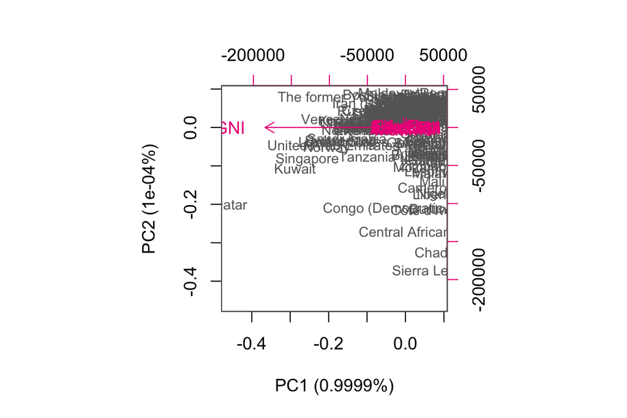

```r
pc_lab <- paste0(names(pca_percent), " (", pca_percent, "%)")

biplot(pca_human, cex = c(0.8, 1), col = c("grey40", "deeppink2"), xlab = pc_lab[1], ylab = pc_lab[2])
```

## 3. Standardize the variables in the human data and repeat the above analysis

We will now perform the same operation, but this time we will standardize the variable, so that they are more easily comparable

```r
human_standard <- scale(human)

pca_human_standard <- prcomp(human_standard)

summary_human_standard <- summary(pca_human_standard)

summary_human_standard
```

```
## Importance of components:
##                          PC1    PC2     PC3     PC4     PC5     PC6     PC7
## Standard deviation     2.071 1.1397 0.87505 0.77886 0.66196 0.53631 0.45900
## Proportion of Variance 0.536 0.1624 0.09571 0.07583 0.05477 0.03595 0.02634
## Cumulative Proportion  0.536 0.6984 0.79413 0.86996 0.92473 0.96069 0.98702
##                            PC8
## Standard deviation     0.32224
## Proportion of Variance 0.01298
## Cumulative Proportion  1.00000
```

```r
pca_percent_standard <- round(1*summary_human_standard$importance[2, ], digits = 5)

pca_percent_standard
```

```
##     PC1     PC2     PC3     PC4     PC5     PC6     PC7     PC8
## 0.53605 0.16237 0.09571 0.07583 0.05477 0.03595 0.02634 0.01298
```

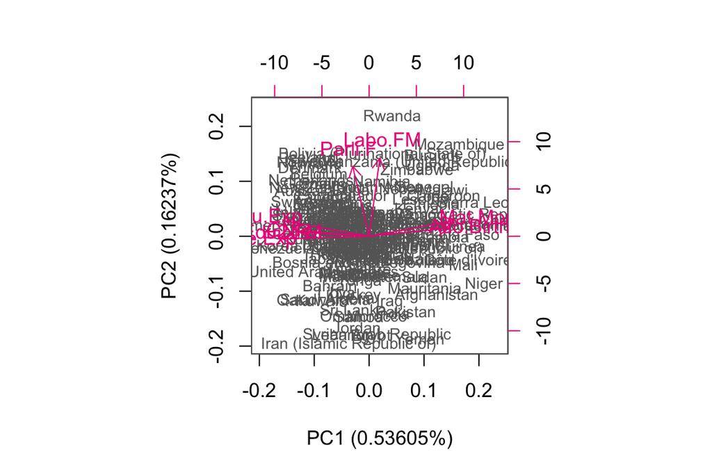

```r
pc_lab_standard <- paste0(names(pca_percent_standard), " (", pca_percent_standard, "%)")

biplot(pca_human_standard, cex = c(0.8, 1), col = c("grey40", "deeppink2"), xlab = pc_lab_standard[1], ylab = pc_lab_standard[2])
```

Variables like life expectancy, expected years of education, and education experience, all go together nicely, as one might expect, while maternal mortality and adolescent birth rate go together, but in the opposite direction.

# Analysis of Longitudinal Data

## Part 1: Implement Chapter 8 MABS exercise, but with **RATS** data

### 6.1 Meet and Repeat with RATS

First, lets load up some libraries that we might need for these exercises…

```r
library(tidyverse)
```

```r
library(tidyr)
library(dplyr)
library(GGally)
library(corrplot)
library(ggplot2)
library(lme4)
```

#### Reading in the data…

We are now going to read in some data about a study of three groups of rats, put on different diets, who were weighted (approximately) weekly over a nine-week period. Let’s take a look at some basic features of the data.

```r
RATS <- read.table("https://raw.githubusercontent.com/KimmoVehkalahti/MABS/master/Examples/data/rats.txt", header = TRUE, sep = '\t')

names(RATS)
```

```
##  [1] "ID"    "Group" "WD1"   "WD8"   "WD15"  "WD22"  "WD29"  "WD36"  "WD43"
## [10] "WD44"  "WD50"  "WD57"  "WD64"
```

```r
str(RATS)
```

```
## 'data.frame':    16 obs. of  13 variables:
##  $ ID   : int  1 2 3 4 5 6 7 8 9 10 ...
##  $ Group: int  1 1 1 1 1 1 1 1 2 2 ...
##  $ WD1  : int  240 225 245 260 255 260 275 245 410 405 ...
##  $ WD8  : int  250 230 250 255 260 265 275 255 415 420 ...
##  $ WD15 : int  255 230 250 255 255 270 260 260 425 430 ...
##  $ WD22 : int  260 232 255 265 270 275 270 268 428 440 ...
##  $ WD29 : int  262 240 262 265 270 275 273 270 438 448 ...
##  $ WD36 : int  258 240 265 268 273 277 274 265 443 460 ...
##  $ WD43 : int  266 243 267 270 274 278 276 265 442 458 ...
##  $ WD44 : int  266 244 267 272 273 278 271 267 446 464 ...
##  $ WD50 : int  265 238 264 274 276 284 282 273 456 475 ...
##  $ WD57 : int  272 247 268 273 278 279 281 274 468 484 ...
##  $ WD64 : int  278 245 269 275 280 281 284 278 478 496 ...
```

```r
summary(RATS)
```

```
##        ID            Group           WD1             WD8             WD15
##  Min.   : 1.00   Min.   :1.00   Min.   :225.0   Min.   :230.0   Min.   :230.0
##  1st Qu.: 4.75   1st Qu.:1.00   1st Qu.:252.5   1st Qu.:255.0   1st Qu.:255.0
##  Median : 8.50   Median :1.50   Median :340.0   Median :345.0   Median :347.5
##  Mean   : 8.50   Mean   :1.75   Mean   :365.9   Mean   :369.1   Mean   :372.5
##  3rd Qu.:12.25   3rd Qu.:2.25   3rd Qu.:480.0   3rd Qu.:476.2   3rd Qu.:486.2
##  Max.   :16.00   Max.   :3.00   Max.   :555.0   Max.   :560.0   Max.   :565.0
##       WD22            WD29            WD36            WD43
##  Min.   :232.0   Min.   :240.0   Min.   :240.0   Min.   :243.0
##  1st Qu.:267.2   1st Qu.:268.8   1st Qu.:267.2   1st Qu.:269.2
##  Median :351.5   Median :356.5   Median :360.0   Median :360.0
##  Mean   :379.2   Mean   :383.9   Mean   :387.0   Mean   :386.0
##  3rd Qu.:492.5   3rd Qu.:497.8   3rd Qu.:504.2   3rd Qu.:501.0
##  Max.   :580.0   Max.   :590.0   Max.   :597.0   Max.   :595.0
##       WD44            WD50            WD57            WD64
##  Min.   :244.0   Min.   :238.0   Min.   :247.0   Min.   :245.0
##  1st Qu.:270.0   1st Qu.:273.8   1st Qu.:273.8   1st Qu.:278.0
##  Median :362.0   Median :370.0   Median :373.5   Median :378.0
##  Mean   :388.3   Mean   :394.6   Mean   :398.6   Mean   :404.1
##  3rd Qu.:510.5   3rd Qu.:516.0   3rd Qu.:524.5   3rd Qu.:530.8
##  Max.   :595.0   Max.   :612.0   Max.   :618.0   Max.   :628.0
```

The data looks comprehensible, but there are a few issues that will cause us trouble that need addressing. Our columns have weeks with day numbers on them, indicating when the rats were weighed, though they’re in an awkward form that we will change. Here we should notice that this data is in a **wide** form, which could cause us some problems. We will convert it to **long** form below.

### 6.2 Prepare for graphical display with a “pivot”

We will also add a variable called “Time” to adjust the given form of the time the rats were weight, which will use the day rather than the original week format.

```r
RATSL <- pivot_longer(RATS, cols = -c(ID, Group),
                      names_to = "WD",
                      values_to = "Weight") %>%
         mutate(Time = as.integer(substr(WD,3,4))) %>%
         arrange(Time)
```

We will also change the problematic ID and Group variables to factors, instead of their original form of integers.

```r
RATSL$ID <- factor(RATSL$ID)
RATSL$Group <- factor(RATSL$Group)
```

### 6.3 Individuals on the plot

Now let’s take a look at some plots of the data.

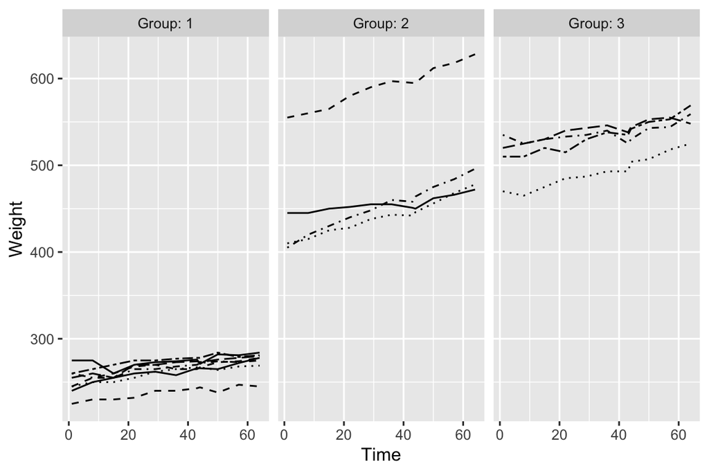

```r
library(ggplot2)
ggplot(RATSL, aes(x = Time, y = Weight, linetype = ID)) +
  geom_line() +
  scale_linetype_manual(values = rep(1:10, times=4)) +
  facet_grid(. ~ Group, labeller = label_both) +
  theme(legend.position = "none") +
  scale_y_continuous(limits = c(min(RATSL$Weight), max(RATSL$Weight)))
```

Well, it looks like all rats gained weight over time, and there was one super heavy rat in group two!!

### 6.4 Standardization

Let’s do that again, only this time, we are going to standardize the data to make things more comparable between groups.

```r
library(dplyr)
library(tidyr)

RATSL <- RATSL %>%
  group_by(Time) %>%
  mutate(standardrats = (Weight - mean(Weight))/sd(Weight)) %>%
  ungroup()

glimpse(RATSL)
```

```
## Rows: 176
## Columns: 6
## $ ID           <fct> 1, 2, 3, 4, 5, 6, 7, 8, 9, 10, 11, 12, 13, 14, 15, 16, 1,…
## $ Group        <fct> 1, 1, 1, 1, 1, 1, 1, 1, 2, 2, 2, 2, 3, 3, 3, 3, 1, 1, 1, …
## $ WD           <chr> "WD1", "WD1", "WD1", "WD1", "WD1", "WD1", "WD1", "WD1", "…
## $ Weight       <int> 240, 225, 245, 260, 255, 260, 275, 245, 410, 405, 445, 55…
## $ Time         <int> 1, 1, 1, 1, 1, 1, 1, 1, 1, 1, 1, 1, 1, 1, 1, 1, 8, 8, 8, …
## $ standardrats <dbl> -1.0011429, -1.1203857, -0.9613953, -0.8421525, -0.881900…
```

#### PLOT AGAIN!

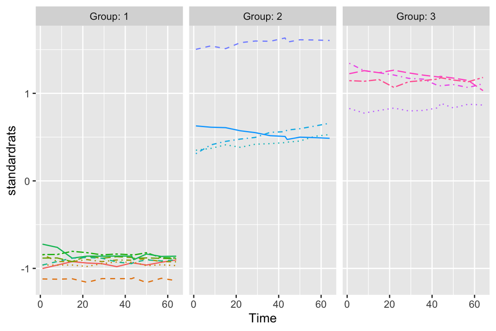

```r
ggplot(RATSL, aes(x = Time, y = standardrats, col = ID, linetype = ID)) +
  geom_line() +
  scale_linetype_manual(values = rep(1:10, times=4)) +
  facet_grid(. ~ Group, labeller = label_both) +
  theme(legend.position = "none") +
  scale_y_continuous(limits = c(min(RATSL$standardrats), max(RATSL$standardrats)))
```

Now that the data has been standardized, we can see relative consistency within the groups (excluding, of course, our very large rat in group 2!)

### 6.5 Summary graph

We will now do another graph to take a look at the variation within the observations.

```r
library(dplyr)
library(tidyr)
# Summary data with mean and standard error of bprs by treatment and week
RATSLS <- RATSL %>%
  group_by(Group, Time) %>%
  summarise( mean = mean(Weight), se = sd(Weight)/sqrt(Weight) ) %>%
  ungroup()
glimpse(RATSLS)
```

```
## Rows: 176
## Columns: 4
## $ Group <fct> 1, 1, 1, 1, 1, 1, 1, 1, 1, 1, 1, 1, 1, 1, 1, 1, 1, 1, 1, 1, 1, 1…
## $ Time  <int> 1, 1, 1, 1, 1, 1, 1, 1, 8, 8, 8, 8, 8, 8, 8, 8, 15, 15, 15, 15, …
## $ mean  <dbl> 250.625, 250.625, 250.625, 250.625, 250.625, 250.625, 250.625, 2…
## $ se    <dbl> 0.9825486, 1.0147718, 0.9724709, 0.9440022, 0.9532122, 0.9440022…
```

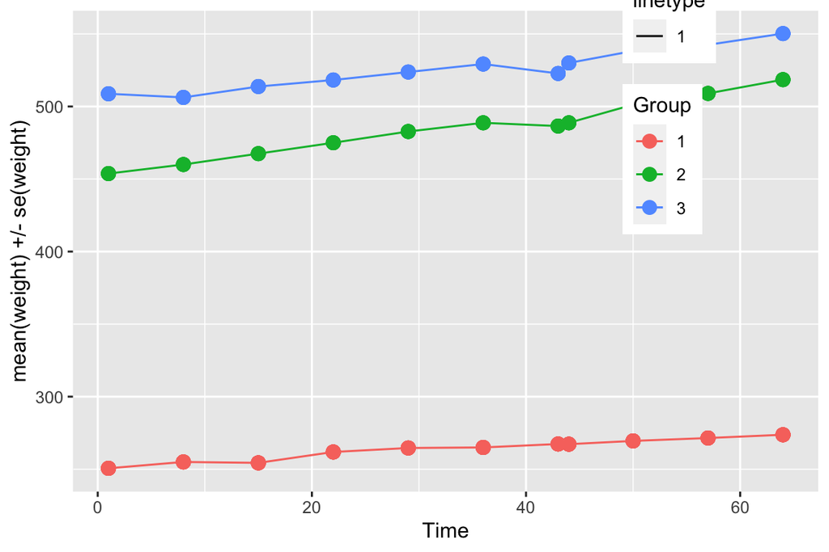

```r
library(ggplot2)
ggplot(RATSLS, aes(x = Time, y = mean, col = Group)) +
  geom_line() +
  scale_linetype_manual(values = c(1,2,3)) +
  geom_point(size=3) +
  scale_shape_manual(values = c(1,2,3)) +
  geom_errorbar(aes(ymin=mean-se, ymax=mean+se, linetype="1"), width=0.3) +
  theme(legend.position = c(0.8,0.8)) +
  scale_y_continuous(name = "mean(weight) +/- se(weight)")
```

### 6.6 Outliers lurking

We are coming for you, fat rat… Let’s take a closer look at the mean weights of all the rats.

```r
library(dplyr)
library(tidyr)

RATSLsum <- RATSL %>%
  filter(Time > 1) %>%
  group_by(Group, ID) %>%
  summarise( mean=mean(Weight) ) %>%
  ungroup()
glimpse(RATSLsum)
```

```
## Rows: 16
## Columns: 3
## $ Group <fct> 1, 1, 1, 1, 1, 1, 1, 1, 2, 2, 2, 2, 3, 3, 3, 3
## $ ID    <fct> 1, 2, 3, 4, 5, 6, 7, 8, 9, 10, 11, 12, 13, 14, 15, 16
## $ mean  <dbl> 263.2, 238.9, 261.7, 267.2, 270.9, 276.2, 274.6, 267.5, 443.9, 4…
```

And now with a box plot, we can see.

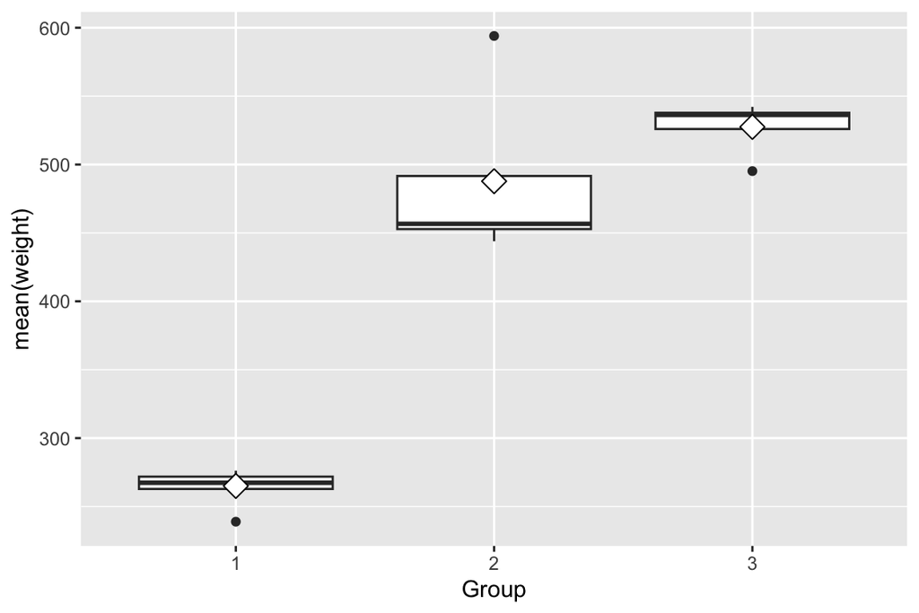

```r
library(ggplot2)
ggplot(RATSLsum, aes(x = Group, y = mean)) +
  geom_boxplot() +
  stat_summary(fun = "mean", geom = "point", shape=23, size=4, fill = "white") +
  scale_y_continuous(name = "mean(weight)")
```

There, at nearly 600, is the one outlier fat rat, distorting our precious data…. Sorry, you’re going to get filtered out.

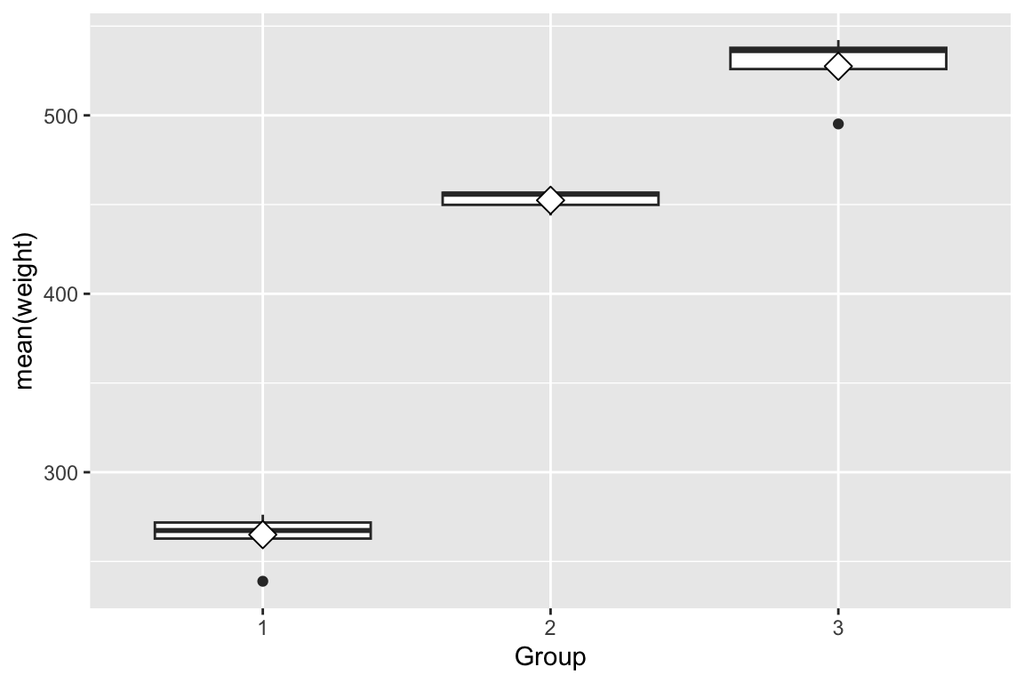

```r
RATSLfiltered <- RATSLsum %>% filter(mean < 550)
library(ggplot2)
ggplot(RATSLfiltered, aes(x = Group, y = mean)) +
  geom_boxplot() +
  stat_summary(fun = "mean", geom = "point", shape=23, size=4, fill = "white") +
  scale_y_continuous(name = "mean(weight)")
```

### 6.7 Anova and t test

First, the T test.

```r
RATSLsum1 <- RATSLsum %>% filter(Group!=1)
t.test(mean ~ Group, data = RATSLsum1, var.equal = TRUE)
```

```
##
##  Two Sample t-test
##
## data:  mean by Group
## t = -1.0686, df = 6, p-value = 0.3263
## alternative hypothesis: true difference in means between group 2 and group 3 is not equal to 0
## 95 percent confidence interval:
##  -130.60428   51.20428
## sample estimates:
## mean in group 2 mean in group 3
##           487.8           527.5
```

(sorry I got stuck here)